```python
import pandas as pd
import numpy as np
import matplotlib.pyplot as plt
pd.set_option('max_columns',1000)
pd.set_option('max_row',300)
# %matplotlib notebook
%matplotlib inline
import math
import seaborn as sns
import plotly.graph_objects as go
import plotly.express as px
```

```python
country_list = pd.DataFrame()
```

# 1. World_Development_Indicators Analysis

# Clean and get data summary

```python
data_indicator = pd.read_csv('World_Development_Indicators.csv')
data_indicator.head()
```

|  | Series Name | Series Code | Country Name | Country Code | 1990 [YR1990] | 2000 [YR2000] | 2011 [YR2011] | 2012 [YR2012] | 2013 [YR2013] | 2014 [YR2014] | 2015 [YR2015] | 2016 [YR2016] | 2017 [YR2017] | 2018 [YR2018] | 2019 [YR2019] | 2020 [YR2020] |
| --- | --- | --- | --- | --- | --- | --- | --- | --- | --- | --- | --- | --- | --- | --- | --- | --- |
| 0 | Population, total | SP.POP.TOTL | Afghanistan | AFG | 12412308 | 20779953 | 30117413 | 31161376 | 32269589 | 33370794 | 34413603 | 35383128 | 36296400 | 37172386 | 38041754 | .. |
| 1 | Population, total | SP.POP.TOTL | Albania | ALB | 3286542 | 3089027 | 2905195 | 2900401 | 2895092 | 2889104 | 2880703 | 2876101 | 2873457 | 2866376 | 2854191 | .. |
| 2 | Population, total | SP.POP.TOTL | Algeria | DZA | 25758869 | 31042235 | 36661444 | 37383887 | 38140132 | 38923687 | 39728025 | 40551404 | 41389198 | 42228429 | 43053054 | .. |
| 3 | Population, total | SP.POP.TOTL | American Samoa | ASM | 47347 | 57821 | 55759 | 55667 | 55713 | 55791 | 55812 | 55741 | 55620 | 55465 | 55312 | .. |
| 4 | Population, total | SP.POP.TOTL | Andorra | AND | 54509 | 65390 | 83747 | 82427 | 80774 | 79213 | 78011 | 77297 | 77001 | 77006 | 77142 | .. |

### there are 264 countries' data in this dataset

```python
data_indicator['Series Name'].value_counts()
```

```
Population, total                                      264
Surface area (sq. km)                                  264
Population density (people per sq. km of land area)    264
GNI, Atlas method (current US$)                        264
GNI per capita, Atlas method (current US$)             264
GNI, PPP (current international $)                     264
GNI per capita, PPP (current international $)          264
GDP growth (annual %)                                  264
GDP per capita growth (annual %)                       264
Data from database: World Development Indicators         1
Last Updated: 02/17/2021                                 1
Name: Series Name, dtype: int64
```

### Kept not N/A data from year 2015 to 2019

```python
five_yr = data_indicator[['Series Name', 'Country Name', 'Country Code',
                          '2015 [YR2015]','2016 [YR2016]','2017 [YR2017]','2018 [YR2018]', '2019 [YR2019]']]
five_yr = five_yr.dropna() #去掉空value

five_yr = five_yr[~five_yr['2016 [YR2016]'].str.startswith('..')] #去掉没有数据的row
five_yr = five_yr[~five_yr['2015 [YR2015]'].str.startswith('..')]
five_yr = five_yr[~five_yr['2017 [YR2017]'].str.startswith('..')]
five_yr = five_yr[~five_yr['2018 [YR2018]'].str.startswith('..')]
five_yr = five_yr[~five_yr['2019 [YR2019]'].str.startswith('..')]
# five_yr.head()
five_yr = five_yr.apply(pd.to_numeric, errors='ignore')
five_yr['mean'] = five_yr.iloc[:, 3:].mean(axis=1)
five_yr.head()
```

|  | Series Name | Country Name | Country Code | 2015 [YR2015] | 2016 [YR2016] | 2017 [YR2017] | 2018 [YR2018] | 2019 [YR2019] | mean |
| --- | --- | --- | --- | --- | --- | --- | --- | --- | --- |
| 0 | Population, total | Afghanistan | AFG | 34413603.0 | 35383128.0 | 36296400.0 | 37172386.0 | 38041754.0 | 36261454.2 |
| 1 | Population, total | Albania | ALB | 2880703.0 | 2876101.0 | 2873457.0 | 2866376.0 | 2854191.0 | 2870165.6 |
| 2 | Population, total | Algeria | DZA | 39728025.0 | 40551404.0 | 41389198.0 | 42228429.0 | 43053054.0 | 41390022.0 |
| 3 | Population, total | American Samoa | ASM | 55812.0 | 55741.0 | 55620.0 | 55465.0 | 55312.0 | 55590.0 |
| 4 | Population, total | Andorra | AND | 78011.0 | 77297.0 | 77001.0 | 77006.0 | 77142.0 | 77291.4 |

## processed Gni PPP data : gni_ppp

- The larger the more well developed the country is

```python
gni_ppp = five_yr[(five_yr["Series Name"]== "GNI per capita, PPP (current international $)" )]
# gni_ppp.count() --> 229
# gni_ppp = gni_ppp.apply(pd.to_numeric, errors='ignore')
gni_ppp = gni_ppp.sort_values(by='mean', ascending=True)
```

```python
gni_ppp['mean'].describe()
```

```
count      229.000000
mean     19102.616159
std      18636.438086
min        796.000000
25%       4838.000000
50%      13068.000000
75%      26580.000000
max      89572.000000
Name: mean, dtype: float64
```

#### kept 25%-50% quantile

```python
processed_gni = gni_ppp[(gni_ppp['mean'] >= 4838.000000) & ( gni_ppp['mean'] <= 13068.000000)]
# 塞进country_list里面
country_ls1 = pd.DataFrame(processed_gni['Country Name'])
# country_ls1
# processed_gni
# processed_gni
```

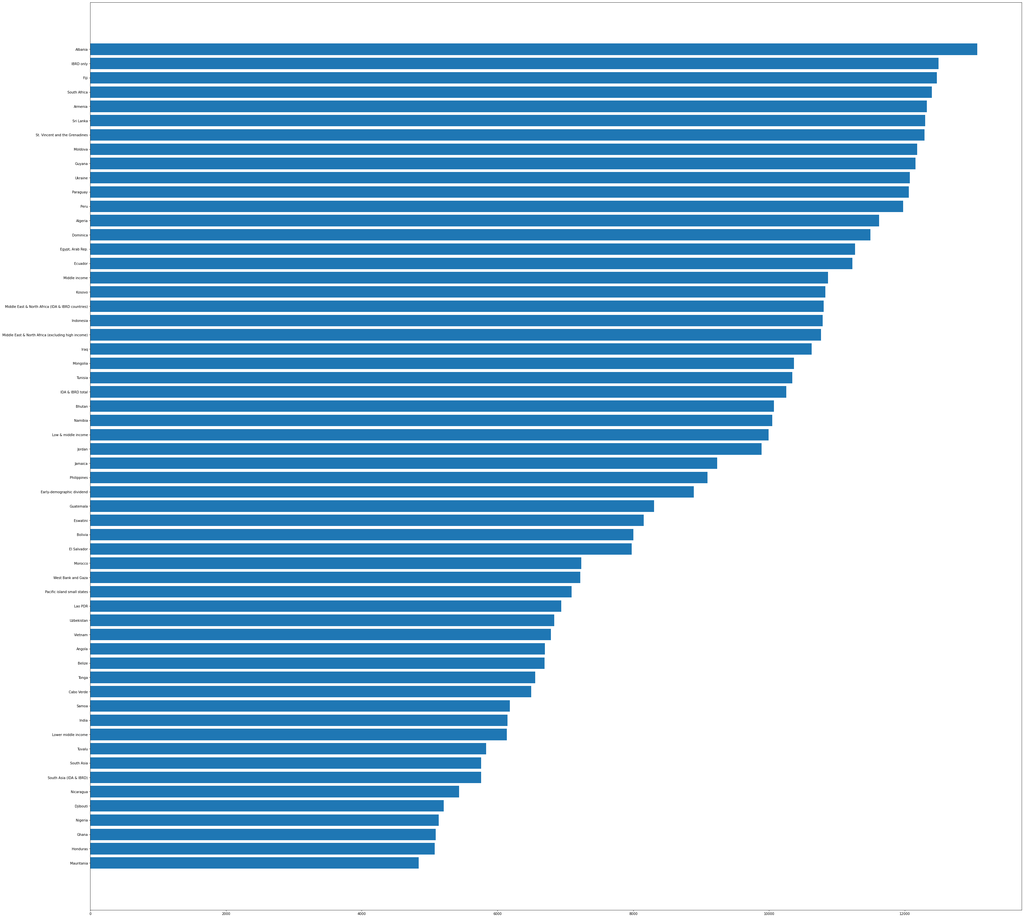

```python
country = processed_gni['Country Name']
country.head(30)
y_pos = np.arange(len(country))
plt.yticks(y_pos,country)
plt.barh(y_pos,processed_gni['mean'],align = 'center')
plt.rcParams["figure.figsize"] = (20,20)
```

## Processed GDP Percapita growth data: gdp_percap_growth

- small refers to more well developed countries are

```python
gdp_percap_growth = five_yr[(five_yr["Series Name"]== "GDP per capita growth (annual %)" )]
# gdp_percap_growth.count()   -- > 234
processed_gdp = gdp_percap_growth.sort_values(by='mean', ascending=False).head(60)
country_ls2 = pd.DataFrame(processed_gdp['Country Name'])
country_ls2
# processed_gdp
```

|  | Country Name |
| --- | --- |
| 2205 | Ireland |
| 2127 | Bangladesh |
| 2153 | China |
| 2176 | Ethiopia |
| 2323 | Vietnam |
| 2334 | East Asia & Pacific (excluding high income) |
| 2335 | East Asia & Pacific (IDA & IBRD countries) |
| 2201 | India |
| 2166 | Djibouti |
| 2145 | Cambodia |
| 2272 | Romania |
| 2369 | South Asia |
| 2370 | South Asia (IDA & IBRD) |
| 2225 | Libya |
| 2247 | Myanmar |
| 2267 | Philippines |
| 2168 | Dominican Republic |
| 2241 | Moldova |
| 2220 | Lao PDR |
| 2159 | Cote d'Ivoire |
| 2274 | Rwanda |
| 2227 | Lithuania |
| 2193 | Guinea |
| 2313 | Tuvalu |
| 2268 | Poland |
| 2120 | Armenia |
| 2302 | Tajikistan |
| 2141 | Bulgaria |
| 2134 | Bhutan |
| 2217 | Kosovo |
| 2331 | Central Europe and the Baltics |
| 2136 | Bosnia and Herzegovina |
| 2199 | Hungary |
| 2184 | Georgia |
| 2244 | Montenegro |
| 2221 | Latvia |
| 2320 | Uzbekistan |
| 2118 | Antigua and Barbuda |
| 2250 | Nepal |
| 2160 | Croatia |
| 2349 | Late-demographic dividend |
| 2202 | Indonesia |
| 2312 | Turks and Caicos Islands |
| 2174 | Estonia |
| 2280 | Serbia |
| 2163 | Cyprus |
| 2356 | Lower middle income |
| 2190 | Grenada |
| 2333 | East Asia & Pacific |
| 2238 | Mauritius |
| 2232 | Malaysia |
| 2164 | Czech Republic |
| 2279 | Senegal |
| 2113 | Albania |
| 2344 | IBRD only |
| 2286 | Slovenia |
| 2235 | Malta |
| 2374 | Upper middle income |
| 2281 | Seychelles |
| 2213 | Kenya |

## prcessed Pop density data size is too small, thus use population in total instead: pop

- small population refers to more developed country

```python
pop_dens = five_yr[(five_yr["Series Name"]== "Population density (people per sq. km of land area)" )]
```

```python
#这里是population in total
pop = five_yr[(five_yr["Series Name"]== "Population, total" )]
# pop.count() --> 262
processed_pop = pop.sort_values(by='mean', ascending=False).head(60)
country_ls3 = pd.DataFrame(processed_pop['Country Name'])
country_ls3
```

|  | Country Name |
| --- | --- |
| 263 | World |
| 233 | IDA & IBRD total |
| 242 | Low & middle income |
| 248 | Middle income |
| 232 | IBRD only |
| 220 | Early-demographic dividend |
| 244 | Lower middle income |
| 262 | Upper middle income |
| 221 | East Asia & Pacific |
| 237 | Late-demographic dividend |
| 222 | East Asia & Pacific (excluding high income) |
| 223 | East Asia & Pacific (IDA & IBRD countries) |
| 258 | South Asia (IDA & IBRD) |
| 257 | South Asia |
| 236 | IDA total |
| 41 | China |
| 251 | OECD members |
| 89 | India |
| 231 | High income |
| 254 | Post-demographic dividend |
| 235 | IDA only |
| 259 | Sub-Saharan Africa |
| 261 | Sub-Saharan Africa (IDA & IBRD countries) |
| 260 | Sub-Saharan Africa (excluding high income) |
| 241 | Least developed countries: UN classification |
| 225 | Europe & Central Asia |
| 255 | Pre-demographic dividend |
| 229 | Fragile and conflict affected situations |
| 230 | Heavily indebted poor countries (HIPC) |
| 243 | Low income |
| 238 | Latin America & Caribbean |
| 240 | Latin America & the Caribbean (IDA & IBRD coun... |
| 239 | Latin America & Caribbean (excluding high income) |
| 234 | IDA blend |
| 227 | Europe & Central Asia (IDA & IBRD countries) |
| 228 | European Union |
| 245 | Middle East & North Africa |
| 217 | Arab World |
| 226 | Europe & Central Asia (excluding high income) |
| 246 | Middle East & North Africa (excluding high inc... |
| 247 | Middle East & North Africa (IDA & IBRD countries) |
| 249 | North America |
| 224 | Euro area |
| 206 | United States |
| 90 | Indonesia |
| 149 | Pakistan |
| 26 | Brazil |
| 144 | Nigeria |
| 15 | Bangladesh |
| 161 | Russian Federation |
| 98 | Japan |
| 127 | Mexico |
| 64 | Ethiopia |
| 155 | Philippines |
| 219 | Central Europe and the Baltics |
| 58 | Egypt, Arab Rep. |
| 211 | Vietnam |
| 73 | Germany |
| 44 | Congo, Dem. Rep. |
| 198 | Turkey |

check countrylist length

```python
len(country_ls1)
```

```
58
```

```python
len(country_ls2)
```

```
60
```

```python
len(country_ls3)
```

```
60
```

get a total list

```python
# total_country_ls = country_ls1.append(country_ls2).append(country_ls3)
# count['count'] = pd.DataFrame(total_country_ls.value_counts())
# total_country_ls.value_counts()
# total_country_ls.value_counts()
# rst['general_total'] = rst.iloc[:, 2,5].sum(axis = 1)
# rst

rst = pd.read_csv('processed_country.csv')
rst = rst.dropna()
rst.sort_values(by=['Logistics performance index','general total'], ascending = (False, False))
```

|  | CountryName | Times_appear | ios3 | Logistics performance index | Lead_time import_cost | Documentary compliance_im_cost | Primary_pro_Weighted mean tariff cost | Liner shipping connectivity index | general total |
| --- | --- | --- | --- | --- | --- | --- | --- | --- | --- |
| 0 | China | 2 | CHN | 3.61 | -6.0 | -77.3 | -1.6 | 151.9 | 72.61 |
| 6 | Vietnam | 3 | VNM | 3.27 | -3.0 | -182.5 | -2.7 | 66.5 | -115.43 |
| 3 | India | 3 | IND | 3.18 | -3.0 | -100.0 | -5.7 | 55.5 | -47.02 |
| 7 | Indonesia | 3 | IDN | 3.15 | -4.0 | -164.4 | -2.6 | 44.4 | -120.45 |
| 2 | Philippines | 3 | PHL | 2.90 | -2.0 | -67.5 | -4.0 | 30.6 | -37.00 |
| 10 | Egypt, Arab Rep. | 2 | EGY | 2.82 | -5.0 | -1000.0 | -19.5 | 66.7 | -952.98 |
| 1 | Albania | 2 | ALB | 2.66 | -14.0 | -10.0 | -2.0 | 3.6 | -17.74 |
| 5 | Djibouti | 2 | DJI | 2.63 | -3.0 | -100.0 | -14.1 | 31.4 | -81.07 |
| 8 | Bangladesh | 2 | BGD | 2.58 | -5.0 | -370.0 | -4.7 | 13.3 | -361.82 |
| 9 | Nigeria | 2 | NGA | 2.53 | -2.0 | -564.3 | -8.3 | 21.4 | -548.67 |
| 4 | Moldova | 2 | MDA | 2.46 | -32.0 | -41.1 | -3.3 | 0.7 | -71.24 |

[figure not shown]

```python
import matplotlib.pyplot as plt
import cartopy.io.shapereader as shpreader
import cartopy.crs as ccrs
import cartopy.feature as cfeature

def area(ax, iso, clr) :
    shp = shpreader.natural_earth(resolution='10m',category='cultural',
                                  name='admin_0_countries')
    reader = shpreader.Reader(shp)
    for n in reader.records() :
        if n.attributes['ADM0_A3'] == iso:
            ax.add_geometries([n.geometry], ccrs.PlateCarree(), facecolor=clr,
                              alpha = 1.00, linewidth =0.15, edgecolor = "black",
                              label=n.attributes['ADM0_A3'])
    return ax
iso3 = rst['ios3']
ax = plt.axes(projection=ccrs.Miller())
ax.set_extent([-150, 60, -25, 60])
ax.add_feature(cfeature.COASTLINE)
ax.add_feature(cfeature.BORDERS)
ax.add_feature(cfeature.OCEAN)



for n in iso3 :
    area(ax, n, "royalblue")

plt.rcParams["figure.figsize"] = (50,50)
plt.show()
```

--------------------------------------------------------------------------------

# 2. international_airline_activity Anaysis

**Data Description**  
**PaxIn:** Revenue passengers inbound to Australian city  
**FreightInv:** Revenue freight in tonnes inbound to Australian city  
**MailIn:** Revenue mail in tonnes inbound to Australian city  
**PaxOut:** Revenue passengers outbound from Australian city  
**FreightOut:** Revenue freight in tonnes outbound from Australian city  
**MailOut:** Revenue mail in tonnes outbound from Australian city  
**TotalPax:** Total revenue passengers inbound and outbound from Australian city  
**TotalFreight:** Total revenue freight in tonnes inbound and outbound from Australian city  
**TotalMail:** Total revenue mail in tonnes inbound and outbound from Australian city

## 2.1 Choose year to analysis

```python
year_choice = 2021
#can be change to other years
```

```python
data_airline=pd.read_csv('international_airline_activity.csv')
# data_airline.count()
# data_airline = data_airline[(data_airline["Year"]== 2020) | (data_airline["Year"]== 2021)]#选中上面年份的的数据
data_airline = data_airline[(data_airline["Year"]== year_choice)]
# data_airline['Year'].value_counts()
data_airline = data_airline[~data_airline['FreightOut'].str.startswith('..')]
data_airline2 = data_airline
data_airline.head()
```

[output not shown]

```python
#  + data_airline['ForeignPort'].map(str) + '_'
airpath = data_airline['AustralianPort'].map(str) + ' to ' + data_airline['ForeignPort'] + ' ('+ data_airline['Country']+')'
data_airline['flypath'] = airpath
# airline.value_counts().head(100)
data_airline = data_airline.apply(pd.to_numeric, errors='ignore')
data_airline['TotalFreight'] = data_airline['TotalFreight'].astype(float)
data_airline['FreightOut'] = data_airline['FreightOut'].astype(float)
data_airline.head()
```

[output not shown]

```python
# data_airline.groupby(by = 'Country', as_index= False)['TotalFreight'].sum().sort_values(by='TotalFreight', ascending=False).head(50)
data_airline.groupby(by = 'Country', as_index= False)['FreightOut'].sum().sort_values(by='FreightOut', ascending=False).head(50)
```

[output not shown]

```python
# data_airline.groupby(by = 'flypath', as_index= False)['TotalFreight'].sum().sort_values(by='TotalFreight', ascending=False).head(50)
data_airline.groupby(by = 'flypath', as_index= False)['FreightOut'].sum().sort_values(by='FreightOut', ascending=False).head(50)
```

[output not shown]

## 2.2 due to cotton season in au is in May, Freight data in between May and July are selected to analysis

```python
data_airline_may=pd.read_csv('international_airline_activity.csv')
data_airline_may = data_airline_may[(data_airline_may["Year"]== 2020) | (data_airline_may["Year"]== 2021)]
data_airline_may = data_airline_may[data_airline_may["Month"].str.contains('20-May|20-Jun|20-Jul')]
#  + data_airline['ForeignPort'].map(str) + '_'
airpath = data_airline_may['AustralianPort'].map(str) + ' to ' + data_airline_may['ForeignPort'] + ' ('+ data_airline_may['Country']+')'
data_airline_may['flypath'] = airpath
airline = "Australia" + ' to ' + data_airline_may['Country']
# airline.value_counts().head(100)
data_airline_may['countrypath'] = airline
data_airline_may = data_airline_may[~data_airline_may['FreightOut'].str.startswith('..')]
data_airline_may = data_airline_may.apply(pd.to_numeric, errors='ignore')
# data_airline_may['TotalFreight'] = data_airline_may['TotalFreight'].astype(float)
data_airline_may['FreightOut'] = data_airline_may['FreightOut'].astype(float)
data_airline_may
```

[output not shown]

```python
# data_airline_may.groupby(by = 'Country', as_index= False)['TotalFreight'].sum().sort_values(by='TotalFreight', ascending=False).head(20)
data_airline_may.groupby(by = 'Country', as_index= False)['FreightOut'].sum().sort_values(by='FreightOut', ascending=False).head(20)
```

[output not shown]

```python
# data_airline_may.groupby(by = 'flypath', as_index= False)['TotalFreight'].sum().sort_values(by='TotalFreight', ascending=False).head(40)
data_airline_may.groupby(by = 'flypath', as_index= False)['FreightOut'].sum().sort_values(by='FreightOut', ascending=False).head(40)
```

[output not shown]